# LabReport 2 Assignment Key

# `if(`you do this Lab Report`) {`I will grade it`}`:

# Basic programming in R

The goal of today’s lab for you to learn part of what is generally understood as *control flow*, which describes the order in which parts of your code is evaluated. Today we will focus on conditional execution using `if()` and iterated execution using `for()` loops.

## 1. Conditional execution

1.1. Set your seed (`set.seed()`, putting a number within the parentheses) and save (short for assign) a random number chosen from a uniform distribution (`runif()`) between 20 and 40 without looking at it. Evaluate whether or not the number is greater than or equal to 25, and use `message()` to tell you. Check your answer and repeat this process several times—has it been correctly working?

1.2. Build on 1 by creating a ladder. Create messages within the ladder to tell you if your value is between 20 and 25, 25 and 35, and 35 and 40.

First, drawing a single number between 20 and 40, and using `if()` to let me know if the values is $\geq 25$.

```r
set.seed(6174)
rando <- runif(n = 1, min = 20, max = 40)
if (rando >= 25) {
  message("Chris, your random number is indeed >= 25")
} else {
  message("Chris, your random number is indeed < 25")
}
## Chris, your random number is indeed >= 25
rando
```

```
## [1] 31.8867
```

Second, creating a ladder to determine if the randomly-chosed value between 20 and 40 is between 20 and 25, 25 and 35, or 35 to 40.

```r
rando <- runif(n = 1, min = 20, max = 40)
if (rando >= 35) {
  message("Chris, your random number is between 40 and 35")
} else if (rando >= 25) {
  message("Chris, your random number is beteween 35 and 25")
} else {
  message("Chris, your random number is between 25 and 20")
}
## Chris, your random number is between 25 and 20
rando
```

```
## [1] 20.56131
```

## 2. Looping with `for()`

2.1. Create a `for()` loop that prints out a number sequence between 0 and 100 by 0.01 intervals. Use `print()` within your loop to show what’s happening in the loop as it’s running. After it is fished “raining” values on your screen, include a chunk argument `eval = F` (I just want to see the code, and not the 10,001 values). Congratulations on writing your first loop (presumably)!

2.2. Next, please do some operations in a loop. First, make a counter—an object that keeps track of your loop number. That is, assign an object a value of 0, then loop over it *i* times—let’s say 40. After the loop, what’s the value of the object? Next, create another object that cumulatively sums the loop interation. That is, your first few values should be 1, 3, 6, 10.

2.3. Alas, some ecology! Take the difference equation (discrete time) that models density-indepedent growth. Write a `for()` loop that iterates the equation for 10 timesteps with an initial density of 0.01 and $\lambda = 1.01$. That’s much easier than doing it by hand, isn’t it?

2.4. Take the difference equation that models density-indepedent growth. Write a `for()` loop that iterates the equation for 10 timesteps with an initial density of 100 and $\lambda = 0.99$. Plot the results.

2.5. Using the same conditions of 2.4., write a loop that takes as many steps needed to reach a density of 1. How many steps did it take?

2.6. Let’s now turn to a density-dependent model from this week’s reading: the Ricker model. It’s equation 30 in chapter 1. Simulate this model for 20 timesteps with $r = 0.5$ and $b = 0.1$ from an initial density of 1 and plot it. What is the final density?

2.7. Repeat 2.6 for 10 different values of $r$ (you can choose the values) and plot the final density (vertical axis) against the values of $r$ (horizontal axis). *** 2.1. Making it rain.

```r
seq_2 <- seq(from = 0, to = 100, by = 0.01)
len.seq <- length(seq_2)
for (i in 1:len.seq) {
 raindrop <- seq_2[i]
 print(raindrop)
}
```

2.2. Keeping a counter and performing an operation (cummulative summation).

```r
counter <- 0
sum.counter <- 0
for (i in 1:40) {
  counter <- counter + 1
  sum.counter <- sum.counter + counter
}
message(paste0("The value of the counter is "), counter)
## The value of the counter is 40
message(paste0("The cummulative summation of the counter values is "), sum.counter)
## The cummulative summation of the counter values is 820
```

2.3. Density-indepedent growth

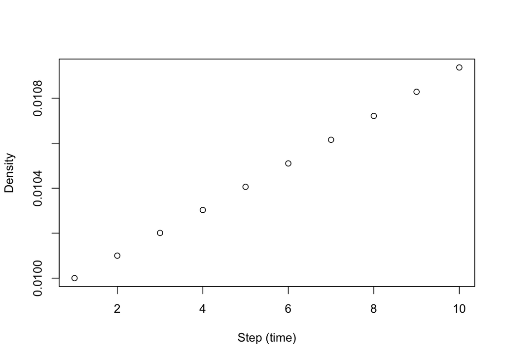

```r
n.steps <- 10
N.vec <- rep(x = NA, times = n.steps)
lambda <- 1.01
N.init <- 0.01
N.vec[1] <- N.init

for (i in 2:n.steps) {
  N.vec[i] <- lambda*N.vec[i-1]
}

plot(x = 1:n.steps, y = N.vec, xlab = "Step (time)", ylab = "Density")
```

2.4. Density-independent growth with $\lambda$ less than 1.

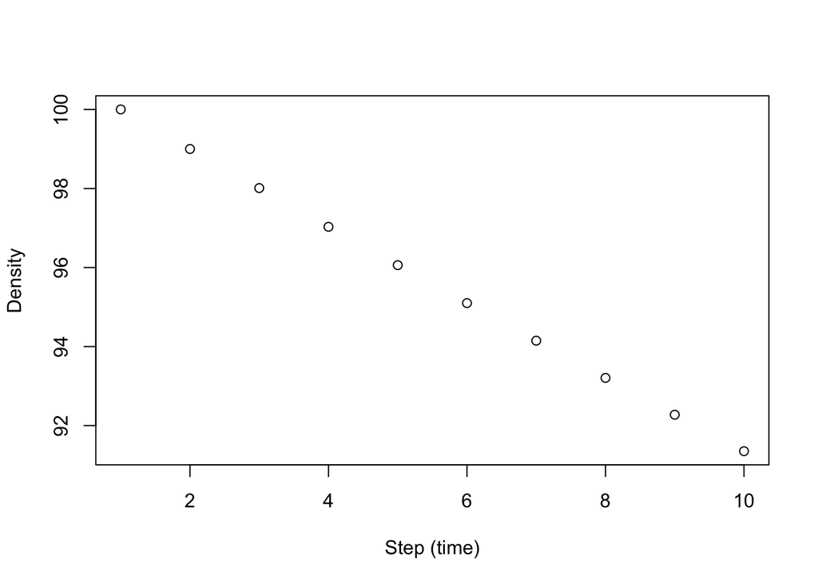

```r
n.steps <- 10
N.vec <- rep(x = NA, times = n.steps)
lambda <- 0.99
N.init <- 100
N.vec[1] <- N.init

for (i in 2:n.steps) {
  N.vec[i] <- lambda*N.vec[i-1]
}

plot(x = 1:n.steps, y = N.vec, xlab = "Step (time)", ylab = "Density")
```

2.5. When does 2.4 reach 1 or less?

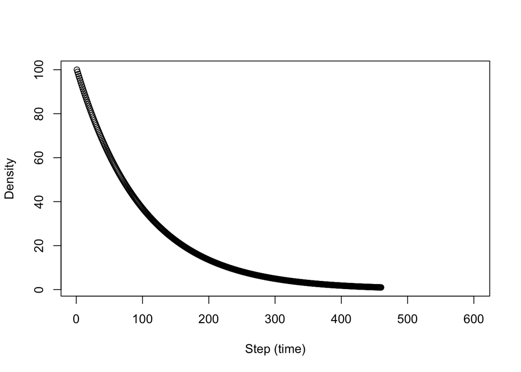

```r
n.steps <- 600
N.vec <- rep(x = NA, times = n.steps)
lambda <- 0.99
N.init <- 100
N.vec[1] <- N.init

for (i in 2:n.steps) {
  if (N.vec[i-1] > 1) {
   N.vec[i] <- lambda*N.vec[i-1]
  } else {
   break
  }
}

plot(x = 1:n.steps, y = N.vec, xlab = "Step (time)", ylab = "Density")
```

2.6.

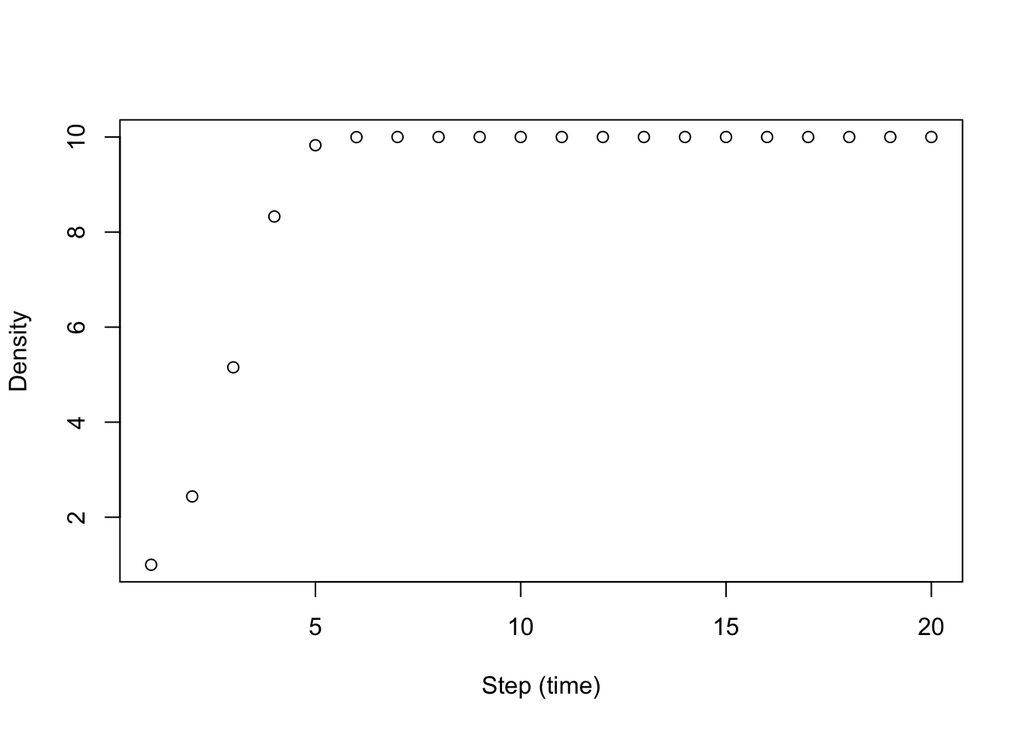

```r
n.steps <- 20
N.vec <- rep(x = NA, times = n.steps)
r <- 0.99
b <- 0.1
N.init <- 1
N.vec[1] <- N.init

for (i in 2:n.steps) {
   N.vec[i] <- N.vec[i-1]*exp(r*(1 - b*N.vec[i-1]))
}

plot(x = 1:n.steps, y = N.vec, xlab = "Step (time)", ylab = "Density")
```

The final density is 10!

2.7.

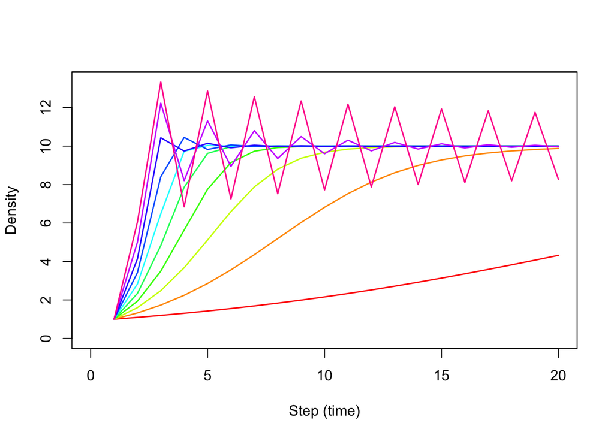

```r
n.steps <- 20
n.rs <- 10
r.vals <- seq(from = 0.1, to = 2, length.out = n.rs)
N.mat <- matrix(data = NA, nrow = n.rs, ncol = n.steps)
b <- 0.1
N.init <- 1
N.mat[, 1] <- N.init

for (i in 1:n.rs) {
  for (j in 2:n.steps) {
    r <- r.vals[i]
    N.mat[i, j] <- N.mat[i, j-1]*exp(r*(1 - b*N.mat[i, j-1]))
  }
}

plot(x = NA, type = "n", xlab = "Step (time)", ylab = "Density", xlim = c(0, n.steps), ylim = c(0, max(N.mat)))
for (k in 1:n.rs) {
  lines(x = 1:n.steps, y = N.mat[k, ], col = rainbow(n = n.rs)[k], lwd = 1.5)
}
```

## 3. (Optional challenge) Nested looping with `for()`

3.1. The lone, optional question in this section asks you to write a nested loop. These come in handy when you want to look at multiple parameters in an ecological model. For the Ricker eqn. in 2.6 we looked at 1 value of $r$ and 1 value of $b$ to find the population density after 20 timesteps. In 2.7 we looked at 1 value of $b$ and 10 values of $r$ to find the density after 20 time steps. But what if we are interested in the Ricker equation across 10 values of $r$ and 10 values of $b$? These nested loops will do this for you. Please construct a nested for loop to analyze 10 values of $r$ between 0.1 and 0.5 and 10 values of $b$ between 0.1 and 1.0. (`seq(from = x, to = y, length.out = 45)` will, for instance, generate 45 values within the interval of `x` and `y`.)

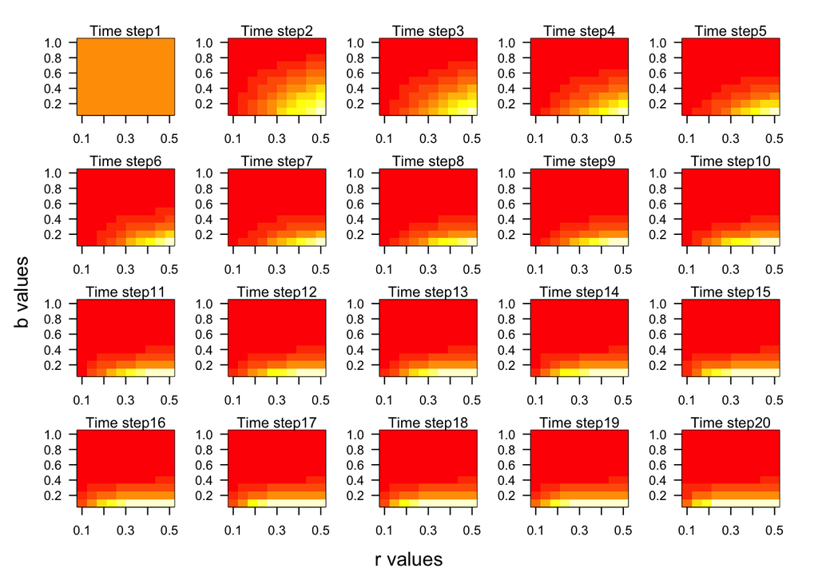

```r
n.steps <- 20
n.rs <- 10
n.bs <- 10
r.vals <- seq(from = 0.1, to = 0.5, length.out = n.rs)
b.vals <- seq(from = 0.1, to = 1.0, length.out = n.bs)
N.arr <- array(data = NA, dim = c(n.rs, n.bs, n.steps))
b <- 0.1
N.init <- 1
N.arr[, , 1] <- N.init

for (i in 1:n.rs) {
  for (j in 1:n.bs) {
    for (k in 2:n.steps) {
      r <- r.vals[i]
      b <- b.vals[j]
      N.arr[i, j, k] <- N.arr[i, j, k-1]*exp(r*(1 - b*N.arr[i, j, k-1]))
    }
  }
}

par(mfrow = c(4, 5), mar = c(3, 3, 0.5, 0.5), oma = c(2, 2, 2, 2)) # mar just sets the whitespace around each panel
for (m in 1:n.steps) {
  image(x = r.vals, y = b.vals, z = N.arr[,,m], las = 1, xlab = "", ylab = "")
  mtext(side = 3, text = paste0("Time step", m), cex = 0.75)
}
mtext(outer = T, side = 1, text = "r values")
mtext(outer = T, side = 2, text = "b values")
```